# week4_dontknockmydoor

Randi Bolt

4/20/2021

## Plan for today

- Visualization in base R

## Data Visulaization in R before ggplot2 * R is a software for statistics it comes with extensive plotting capabilities * MANY plotting functions are installed in the graphics package, whcih ships with base R * Look into the help files for the functions in this package using

```r
library(help = "graphics")
```

- Here are a few examples of visualizations functions in the graphics package: plot, lines, points, abline, boxplot, pairs, matplot, barplot, pie, rasterImage, coplot, cdplot, mosaicplot, polygon

## Data Visualization before ggplot2

plot * plot is gereric function for plotting R objects * Functions in R can be designed in such a way that the same function can have a completely different behavior depending on the object it is used with * Here is a lit with some of the objects it can be applied to

```r
methods(plot)
```

```
##  [1] plot.acf*           plot.data.frame*    plot.decomposed.ts*
##  [4] plot.default        plot.dendrogram*    plot.density*
##  [7] plot.ecdf           plot.factor*        plot.formula*
## [10] plot.function       plot.hclust*        plot.histogram*
## [13] plot.HoltWinters*   plot.isoreg*        plot.lm*
## [16] plot.medpolish*     plot.mlm*           plot.ppr*
## [19] plot.prcomp*        plot.princomp*      plot.profile.nls*
## [22] plot.raster*        plot.spec*          plot.stepfun
## [25] plot.stl*           plot.table*         plot.ts
## [28] plot.tskernel*      plot.TukeyHSD*
## see '?methods' for accessing help and source code
```

## Default

- scatterplots
- structure : plot( x, y, z)
- x is a variable in the x axis
- y in the variable
- … represents other graphical parameters (see ?par for an extensive list)

```r
?par
```

## Data visualization before ggplot2

Eample: the cars dataset * lets load the build- in data **cars** which loads as a dataframe, a type of object mention earlier. Then, we can look at it in a couple different ways. * data(cars) loads this dataframse into the **Global Enviroment** as a promise. Promises are unevaluated arguments.

```r
data(cars)
str(cars, 5) # telling the structure
```

```
## 'data.frame':    50 obs. of  2 variables:
##  $ speed: num  4 4 7 7 8 9 10 10 10 11 ...
##  $ dist : num  2 10 4 22 16 10 18 26 34 17 ...
```

```r
head(cars,4) #shows first four rows
```

```
##   speed dist
## 1     4    2
## 2     4   10
## 3     7    4
## 4     7   22
```

```r
summary(cars) # summary stats for each var (speed and distance)
```

```
##      speed           dist
##  Min.   : 4.0   Min.   :  2.00
##  1st Qu.:12.0   1st Qu.: 26.00
##  Median :15.0   Median : 36.00
##  Mean   :15.4   Mean   : 42.98
##  3rd Qu.:19.0   3rd Qu.: 56.00
##  Max.   :25.0   Max.   :120.00
```

## plot options

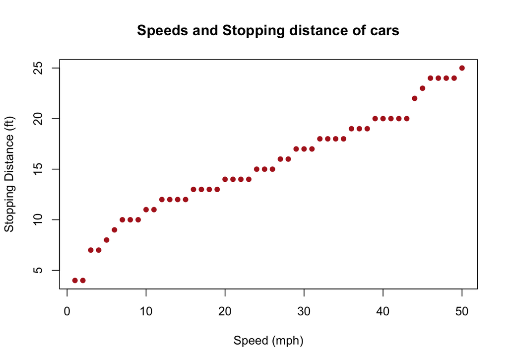

```r
plot(x = cars$speed, y = cars$distance,
     xlab = "Speed (mph)", # x label
     ylab = "Stopping Distance (ft)", # y label
     main = "Speeds and Stopping distance of cars",
     type = "p", # type of plot i.e. points
     lty = 1, lwd = 1, # lty is the line type, 1 is a solid line, 2 dot, 3 dash
                       #lwd is line width
     pch = 16, #plotting character : i.e. circle, squares, triangles, stars
     cex = 1, cex.axis = 1, cex.lab = 1, #character expansion is the point size
               # can highlight specific points(make them bigger)
               # character expansion for axis : want axis to be bigger
               # cex. for labels
     col = "firebrick") #color
```

## Modify Plot type * ‘p’ = points * ‘l’ = lines * ‘b’ = both

## plot option: cex

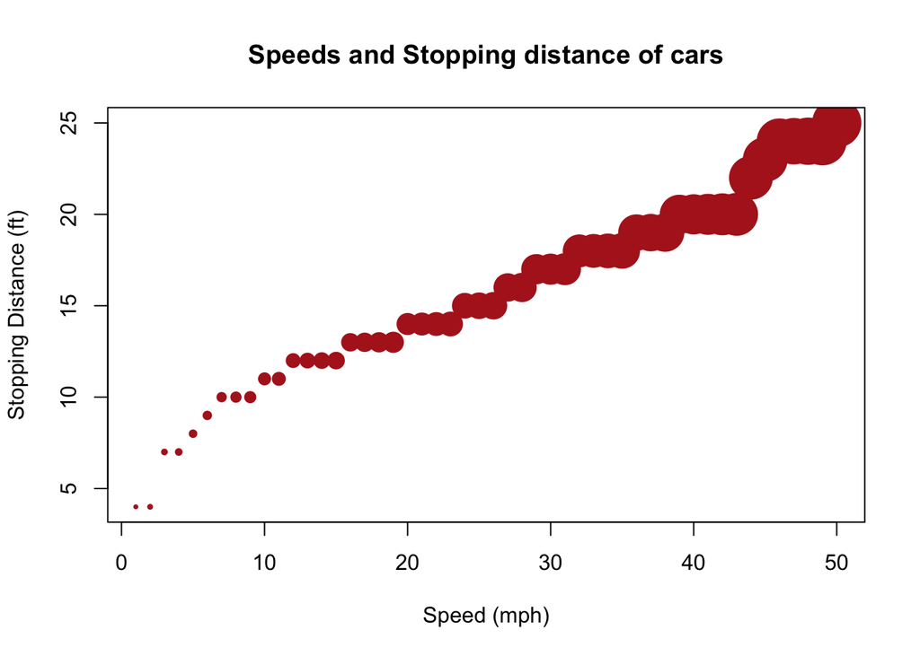

```r
# as speed increases size increases
obj.size <- seq(0.5,5,length.out = length(cars$speed))
plot(x = cars$speed, y = cars$distance,
     xlab = "Speed (mph)",
     ylab = "Stopping Distance (ft)",
     main = "Speeds and Stopping distance of cars",
     type = "p",
     lty = 1, lwd = 1,
     pch = 16,
     cex = obj.size, cex.axis = 1, cex.lab = 1,
     col = "firebrick")
```

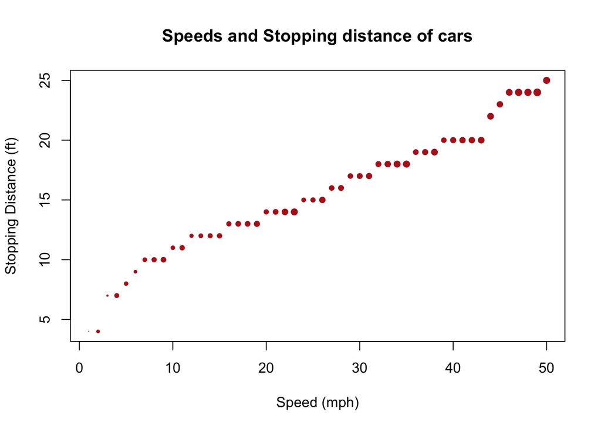

```r
# farther the distance the bigger the plot
obj.size <- log(cars$dist)/4
plot(x = cars$speed, y = cars$distance,
     xlab = "Speed (mph)",
     ylab = "Stopping Distance (ft)",
     main = "Speeds and Stopping distance of cars",
     type = "p",
     lty = 1, lwd = 1,
     pch = 16,
     cex = obj.size, cex.axis = 1, cex.lab = 1,
     col = "firebrick")
```

##plot options : color

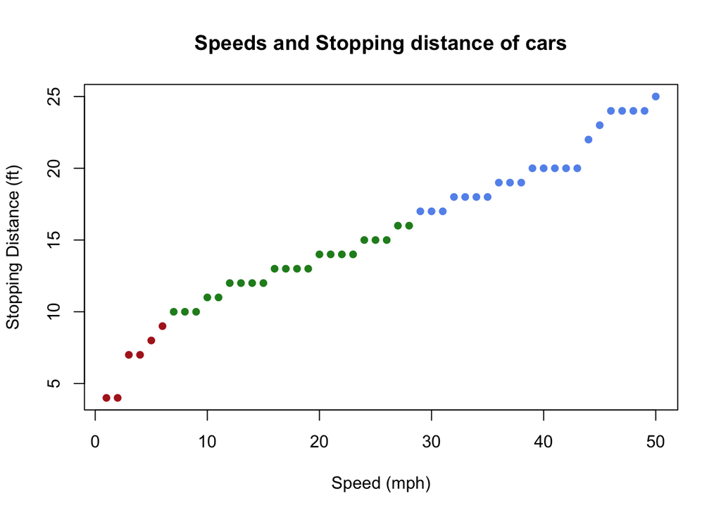

```r
col.vec <- rep(c("firebrick","forestgreen","cornflowerblue"),
               times=c(sum(cars$speed<10),
                       sum(cars$speed>=10&cars$speed<17),
                       sum(cars$speed>=17)))
plot(x = cars$speed, y = cars$distance,
     xlab = "Speed (mph)",
     ylab = "Stopping Distance (ft)",
     main = "Speeds and Stopping distance of cars",
     type = "p",
     lty = 1, lwd = 1,
     pch = 16,
     cex = 1, cex.axis = 1, cex.lab = 1,
     col = col.vec)
```

## Adding a legend

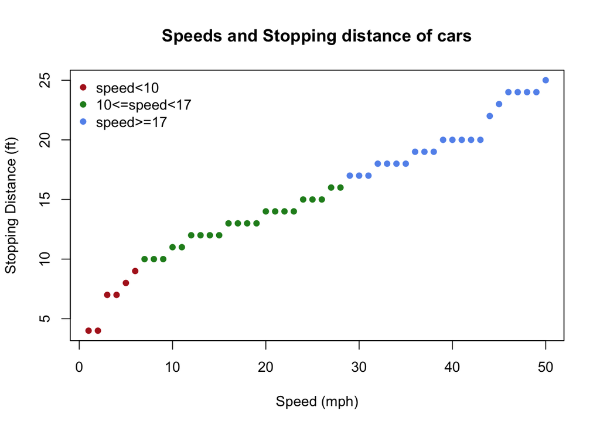

```r
plot(x = cars$speed, y = cars$distance,
     xlab = "Speed (mph)",
     ylab = "Stopping Distance (ft)",
     main = "Speeds and Stopping distance of cars",
     type = "p",
     lty = 1, lwd = 1,
     pch = 16,
     cex = 1, cex.axis = 1, cex.lab = 1,
     col = col.vec)
legend("topleft", #location, topright, bottom, bottomright (look at help)
                  #can plot as vector as well within
       bty = "n", #n mean no box (daniel thinks box looks clunky)
       pch=c(16,16,16),#point type
       col=c("firebrick","forestgreen","cornflowerblue"),
       legend=c("speed<10","10<=speed<17", "speed>=17"))
```

## boxplot

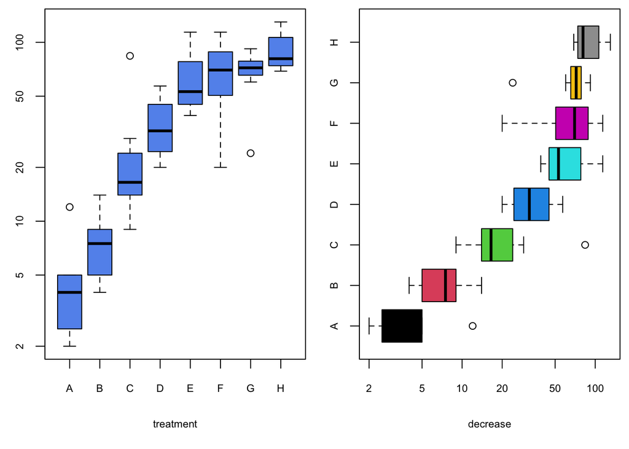

```r
par(mfrow=c(1,2),mai=c(1,0.5,0.1,0.1)) # parameters
                      # modify window showing plot
                      # mai is internal margins
                      # mfrow : graphical device of 1 row with two colomns
boxplot(decrease ~ treatment, data = OrchardSprays, col = "cornflowerblue",
        log = "y",cex.axis=0.7,cex.lab=0.7,notch=F)
## horizontal=TRUE, switching  y <--> x :
boxplot(decrease ~ treatment, data = OrchardSprays, col = 1:8,
        log = "x", horizontal=TRUE,cex.axis=0.7,cex.lab=0.7,notch=F)
```

### Other plots: `curve`

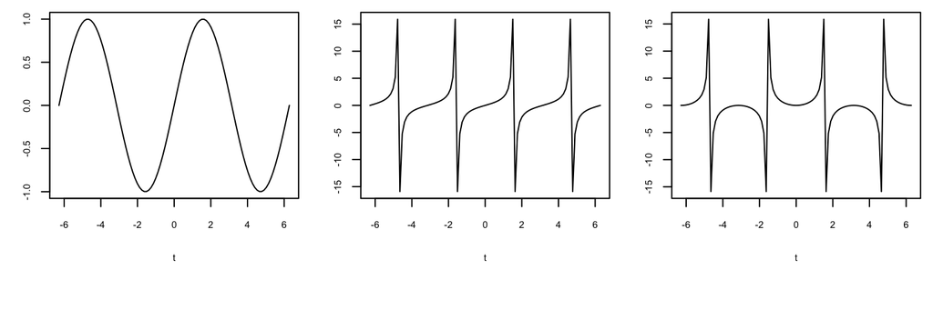

```r
par(mfrow=c(1,3),mai=c(0.9,0.4,0.1,0.1))
curve(expr=sin, from=-2*pi, to=2*pi, xname = "t",cex.axis=0.7, cex.lab=0.7)
curve(expr=tan, xname = "t", from=-2*pi, to=2*pi, cex.axis=0.7, cex.lab=0.7)
myfn <- function(t){tan(t)*sin(t)}
curve(expr=myfn, xname = "t", from=-2*pi, to=2*pi, cex.axis=0.7, cex.lab=0.7)
```

### Other plots: `hist`

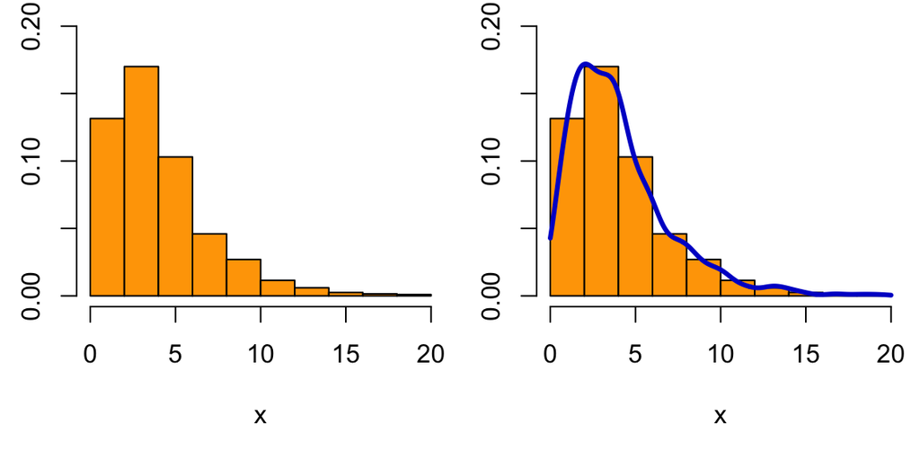

```r
par(mfrow=c(1,2),mai=c(1,0.5,0.1,0.1))
x <- rchisq(1000, df = 4)
hist(x, freq = FALSE, ylim = c(0, 0.2),col="orange",main="")
#hist and curve combined
hist(x, freq = FALSE, ylim = c(0, 0.2),col="orange",main="")
lines(density(x,from=0, to=20), col = "blue3", lty = 1, lwd = 3)
```

```r
# density : dont caluclulate values of the tail
# ylim : limit of the y axis
```

### Other plots: `pairs`

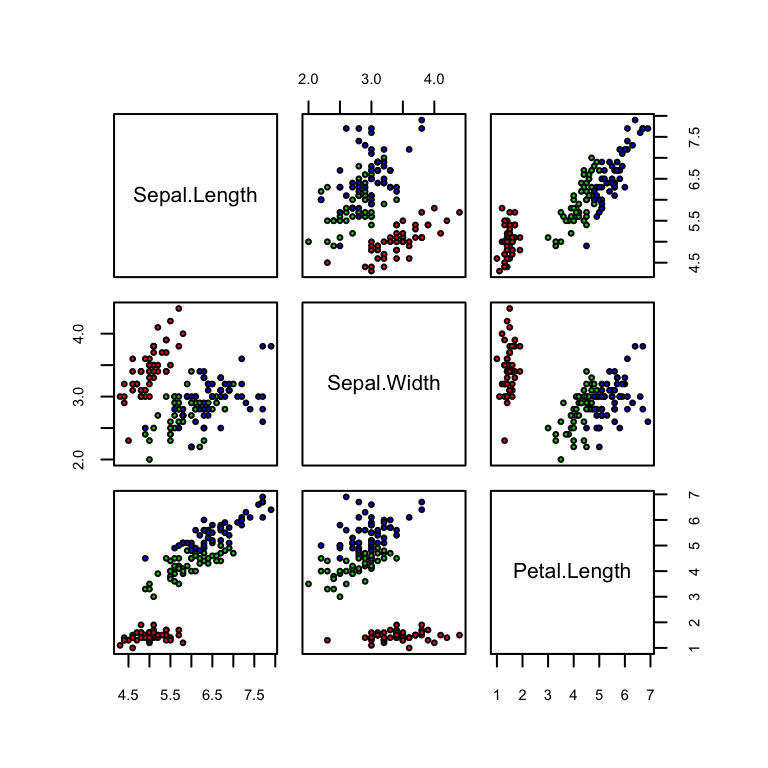

```r
par(mai=c(0.1,0.1,0.1,0.1))
pairs(iris[1:3], cex=0.5, cex.labels = 1,cex.axis=0.7,
      pch = 21, bg = c("red", "green3", "blue")[unclass(iris$Species)])
```

```r
#real type of a vector is an integer vector
data(iris)
iris$Species
```

```
##   [1] setosa     setosa     setosa     setosa     setosa     setosa
##   [7] setosa     setosa     setosa     setosa     setosa     setosa
##  [13] setosa     setosa     setosa     setosa     setosa     setosa
##  [19] setosa     setosa     setosa     setosa     setosa     setosa
##  [25] setosa     setosa     setosa     setosa     setosa     setosa
##  [31] setosa     setosa     setosa     setosa     setosa     setosa
##  [37] setosa     setosa     setosa     setosa     setosa     setosa
##  [43] setosa     setosa     setosa     setosa     setosa     setosa
##  [49] setosa     setosa     versicolor versicolor versicolor versicolor
##  [55] versicolor versicolor versicolor versicolor versicolor versicolor
##  [61] versicolor versicolor versicolor versicolor versicolor versicolor
##  [67] versicolor versicolor versicolor versicolor versicolor versicolor
##  [73] versicolor versicolor versicolor versicolor versicolor versicolor
##  [79] versicolor versicolor versicolor versicolor versicolor versicolor
##  [85] versicolor versicolor versicolor versicolor versicolor versicolor
##  [91] versicolor versicolor versicolor versicolor versicolor versicolor
##  [97] versicolor versicolor versicolor versicolor virginica  virginica
## [103] virginica  virginica  virginica  virginica  virginica  virginica
## [109] virginica  virginica  virginica  virginica  virginica  virginica
## [115] virginica  virginica  virginica  virginica  virginica  virginica
## [121] virginica  virginica  virginica  virginica  virginica  virginica
## [127] virginica  virginica  virginica  virginica  virginica  virginica
## [133] virginica  virginica  virginica  virginica  virginica  virginica
## [139] virginica  virginica  virginica  virginica  virginica  virginica
## [145] virginica  virginica  virginica  virginica  virginica  virginica
## Levels: setosa versicolor virginica
```

```r
unclass(iris$Species)
```

```
##   [1] 1 1 1 1 1 1 1 1 1 1 1 1 1 1 1 1 1 1 1 1 1 1 1 1 1 1 1 1 1 1 1 1 1 1 1 1 1
##  [38] 1 1 1 1 1 1 1 1 1 1 1 1 1 2 2 2 2 2 2 2 2 2 2 2 2 2 2 2 2 2 2 2 2 2 2 2 2
##  [75] 2 2 2 2 2 2 2 2 2 2 2 2 2 2 2 2 2 2 2 2 2 2 2 2 2 2 3 3 3 3 3 3 3 3 3 3 3
## [112] 3 3 3 3 3 3 3 3 3 3 3 3 3 3 3 3 3 3 3 3 3 3 3 3 3 3 3 3 3 3 3 3 3 3 3 3 3
## [149] 3 3
## attr(,"levels")
## [1] "setosa"     "versicolor" "virginica"
```

### Other plots: `dotchart`

```r
VADeaths
```

```
##       Rural Male Rural Female Urban Male Urban Female
## 50-54       11.7          8.7       15.4          8.4
## 55-59       18.1         11.7       24.3         13.6
## 60-64       26.9         20.3       37.0         19.3
## 65-69       41.0         30.9       54.6         35.1
## 70-74       66.0         54.3       71.1         50.0
```

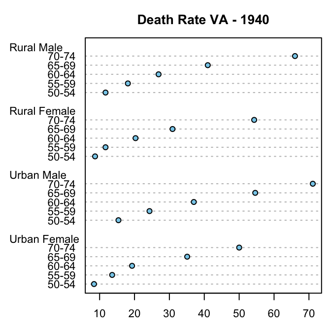

```r
par(mai=c(0.4,0.1,0.4,0.1))
dotchart(VADeaths, bg = "skyblue",
         cex=0.7, cex.axis=0.1,
         main = "Death Rate VA - 1940")
```

### Other plots: `matplot`

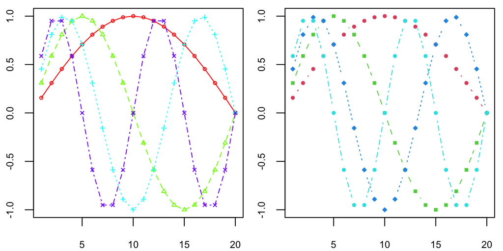

```r
#throw in matrix and give one function per line of matrix
par(mfrow=c(1,2),mai=c(0.4,0.4,0.1,0.1))
#mfrow : enter figures by row (can do mfcol as well)
#takes two vectors, and combine every combination of first and second vector
sines <- outer(1:20, 1:4, function(x, y) sin(x / 20 * pi * y))
# matrix with 20 rows and four columns
# fills in from left to right
matplot(sines, pch = 1:4, type = "o", col = rainbow(ncol(sines)),
        cex=0.5, cex.axis=0.7)
        #rainbow puts as many colors as sines in matrix (which is four)
        #type 'o' : is for overlay , could also have something else here
matplot(sines, type = "b", pch = 21:23, col = 2:5, bg = 2:5,
        cex=0.5, cex.axis=0.7, main = "")
```

```r
        #pch is plotting character
```

## rainbow

```r
rainbow(6)
```

```
## [1] "#FF0000" "#FFFF00" "#00FF00" "#00FFFF" "#0000FF" "#FF00FF"
```

```r
#sines
outer(1:20, 1:4, function(x, y) sin(x / 20 * pi * y))
```

```
##               [,1]          [,2]          [,3]          [,4]
##  [1,] 1.564345e-01  3.090170e-01  4.539905e-01  5.877853e-01
##  [2,] 3.090170e-01  5.877853e-01  8.090170e-01  9.510565e-01
##  [3,] 4.539905e-01  8.090170e-01  9.876883e-01  9.510565e-01
##  [4,] 5.877853e-01  9.510565e-01  9.510565e-01  5.877853e-01
##  [5,] 7.071068e-01  1.000000e+00  7.071068e-01  1.224647e-16
##  [6,] 8.090170e-01  9.510565e-01  3.090170e-01 -5.877853e-01
##  [7,] 8.910065e-01  8.090170e-01 -1.564345e-01 -9.510565e-01
##  [8,] 9.510565e-01  5.877853e-01 -5.877853e-01 -9.510565e-01
##  [9,] 9.876883e-01  3.090170e-01 -8.910065e-01 -5.877853e-01
## [10,] 1.000000e+00  1.224647e-16 -1.000000e+00 -2.449294e-16
## [11,] 9.876883e-01 -3.090170e-01 -8.910065e-01  5.877853e-01
## [12,] 9.510565e-01 -5.877853e-01 -5.877853e-01  9.510565e-01
## [13,] 8.910065e-01 -8.090170e-01 -1.564345e-01  9.510565e-01
## [14,] 8.090170e-01 -9.510565e-01  3.090170e-01  5.877853e-01
## [15,] 7.071068e-01 -1.000000e+00  7.071068e-01  3.673940e-16
## [16,] 5.877853e-01 -9.510565e-01  9.510565e-01 -5.877853e-01
## [17,] 4.539905e-01 -8.090170e-01  9.876883e-01 -9.510565e-01
## [18,] 3.090170e-01 -5.877853e-01  8.090170e-01 -9.510565e-01
## [19,] 1.564345e-01 -3.090170e-01  4.539905e-01 -5.877853e-01
## [20,] 1.224647e-16 -2.449294e-16  3.673940e-16 -4.898587e-16
```

### Other plots: `barplot`

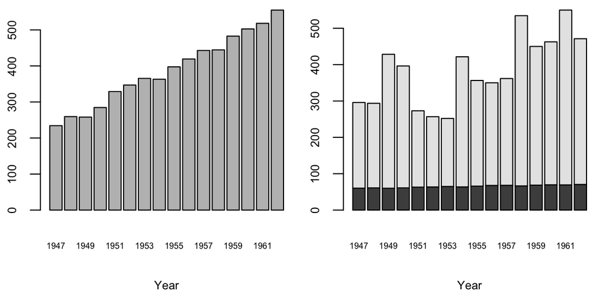

```r
par(mfrow=c(1,2),mai=c(0.9,0.4,0.1,0.1))
barplot(GNP ~ Year, data = longley, cex=0.5, cex.axis=0.7, cex.lab=0.7)
        #formual rep. , give me bar plot by year that shows longly data
        # before ~ represents y (GNP) and after represents x (YEAR)
barplot(cbind(Employed, Unemployed) ~ Year, data = longley, cex = 0.5,
        cex.axis=0.7,cex.lab=0.7)
```

```r
        #plotting two different response variables
        #(employed and unemployed) by year
```

### Other plots: `mosaic`

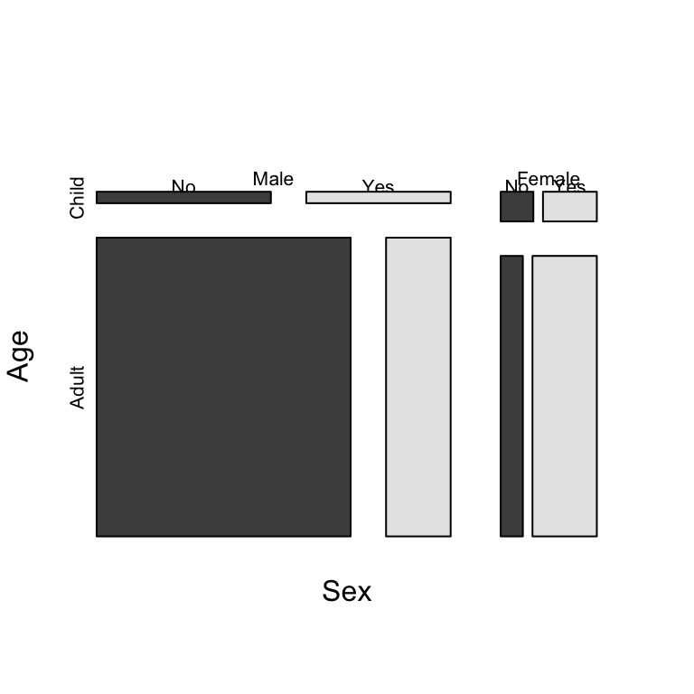

```r
#good for category data (only a few)
par(mfrow=c(1,1),mai=c(0.9,0.4,1,0.4))
mosaicplot(~ Sex + Age + Survived, data = Titanic, main="",color = TRUE)
```

### Figures with multiple panels: `mfrow` (or `mfcol`)

```r
par(mfrow=c(1,3)) #dim of layout matrix 1 row and 3 columns, fill by row not col
plot(x = cars$speed, y = cars$dist,xlab = "", ylab = "", main = "",
     type = "p", pch = 16, col = "firebrick")
plot(x = cars$speed, y = cars$dist,xlab = "", ylab = "", main = "",
     type = "p", pch = 16, col = "firebrick")
abline(reg=lm(dist~speed,data=cars),col="forestgreen")
      # overlaying regression line of slope ontop of previous plot
plot(x = cars$speed, y = cars$dist,xlab = "", ylab = "", main = "",
     type = "p", pch = 16, col = "firebrick")
lines(lowess(cars),col="cornflowerblue")
```

### Figures with multiple panels: `mfrow` (or `mfcol`)

[figure not shown]

### Figures with multiple panels: the `layout` function

```r
layout(mat,
       widths = rep.int(1, ncol(mat)),
       heights = rep.int(1, nrow(mat)),
       respect = FALSE)
```

### Figures with multiple panels: the `layout` function

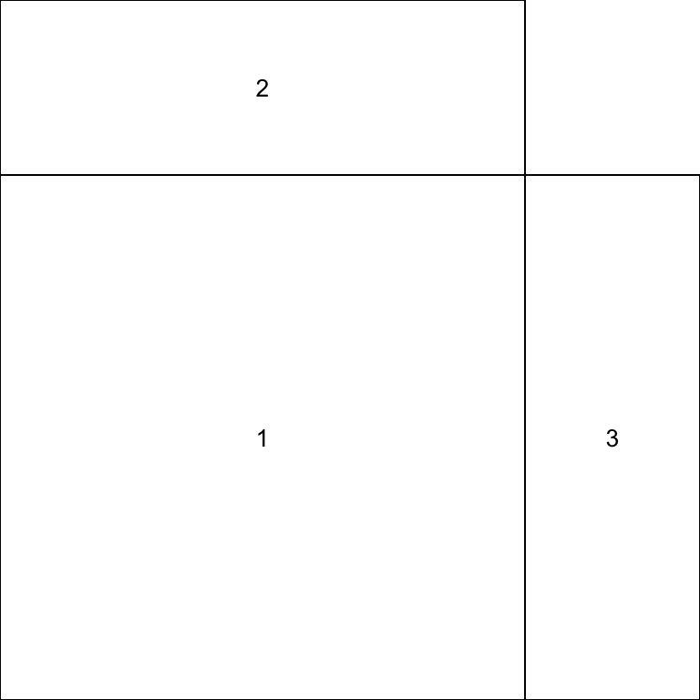

```r
nf <- layout(matrix(c(2,0,1,3),2,2,byrow = TRUE), widths=c(3,1), heights=c(1,3), TRUE)
            # matrix is saying put two upper left, nothing in upper right
            # 1 in lower left, and three in lower right
            #widths / heights : for object
layout.show(nf)
```

### Figures with multiple panels: the `layout` function

```r
nf <- layout(matrix(c(2,0,1,3),ncol=2,nrow=2,byrow = TRUE),
             widths=c(3,1), heights=c(1,3),
             respect=TRUE)

#sample values from two normal distributions
x <- pmin(3, pmax(-3, stats::rnorm(50))) # 50 standard normal and then put
y <- pmin(3, pmax(-3, stats::rnorm(50))) # b/t -3 and 3 for plotting looks good

#generate and store histograms for x and y
xhist <- hist(x, breaks = seq(-3,3,0.5), plot = FALSE) #storing value of hist
yhist <- hist(y, breaks = seq(-3,3,0.5), plot = FALSE)
top <- max(c(xhist$counts, yhist$counts)) #used to defin. upper limit for hists

xrange <- yrange <- c(-3, 3)
    # initializing ranges to use later
par(mar = c(3,3,1,1)) #mar : margins (unsure of order)
plot(x, y, xlim = xrange, ylim = yrange, xlab = "", ylab = "")
    #scatter plot in the middle
par(mar = c(0,3,1,1))
barplot(xhist$counts, axes = FALSE, ylim = c(0, top), space = 0)
    # azes = FALSE : dont plot the axis
    # ylim : 0 to top
    #space = 0 : no spaces b/t bars
par(mar = c(3,0,1,1))
barplot(yhist$counts, axes = FALSE, xlim = c(0, top), space = 0, horiz = TRUE)
```

[output not shown]

## what xhist is storing

```r
x <- pmin(3, pmax(-3, stats::rnorm(50))) # 50 standard normal and then put
y <- pmin(3, pmax(-3, stats::rnorm(50)))
xhist <- hist(x, breaks = seq(-3,3,0.5), plot = FALSE)
xhist
```

```
## $breaks
##  [1] -3.0 -2.5 -2.0 -1.5 -1.0 -0.5  0.0  0.5  1.0  1.5  2.0  2.5  3.0
##
## $counts
##  [1]  0  1  0  5  7  5 16  8  6  0  1  1
##
## $density
##  [1] 0.00 0.04 0.00 0.20 0.28 0.20 0.64 0.32 0.24 0.00 0.04 0.04
##
## $mids
##  [1] -2.75 -2.25 -1.75 -1.25 -0.75 -0.25  0.25  0.75  1.25  1.75  2.25  2.75
##
## $xname
## [1] "x"
##
## $equidist
## [1] TRUE
##
## attr(,"class")
## [1] "histogram"
```